# Knowledge Discovery and Data Visualization Take-home Exam

## Load necessary library

```r
library(ggplot2)
library(scales)
library(corrplot)
library(C50)
library(caret)
library(dplyr)
```

## Load the dataset and generate a random subset

```r
set.seed(2023)

deposit <- read.csv("C:/Users/ichli/OneDrive/Documents/Bsc Business Analytics/Y1/EBC1045_KDDV/Final_Exam/BankDeposit.csv", stringsAsFactors = TRUE)
my_data <- deposit[sample(nrow(deposit), size = 5000),]

head(my_data, 3)
```

```
##      age           job marital education default balance housing loan  contact
## 5584  36    technician  single secondary     yes      12      no   no cellular
## 2479  51 self-employed married   unknown      no    2094      no   no cellular
## 1385  33   blue-collar married   primary      no       0     yes   no  unknown
##      day month duration campaign pdays previous poutcome   y
## 5584  12   aug      587        2    -1        0  unknown yes
## 2479   8   jun      458        6    -1        0  unknown yes
## 1385  15   may      270        1    -1        0  unknown  no
```

## Check for missing value

```r
which( is.na( my_data ) )
```

```
## integer(0)
```

As you can see, there are no missing values in this dataset.

## Identify outliers - IQR Method

Because the presence of -1 in pdays indicates that the client was not previously contacted, and 0 in previous indicates there is no contacts performed before this campaign and for this client, I have decided to remove all -1 and 0 values before finding outliers to avoid incorrect results. Based on this result, you can see the range of outliers in each variables.

```r
find_outliers <- function(x, name) {
  if(is.numeric(x)) {
    if(name == "pdays") {
      x <- x[x != -1]
    }
    if(name == "previous") {
      x <- x[x != 0]
    }

    Q1 <- quantile(x, 0.25, na.rm = TRUE)
    Q3 <- quantile(x, 0.75, na.rm = TRUE)
    IQR <- Q3 - Q1
    lower.bound <- Q1 - 1.5 * IQR
    upper.bound <- Q3 + 1.5 * IQR
    outliers <- x[x < lower.bound | x > upper.bound]
    return(outliers)
  } else {
    return(NA)
  }
}

numeric_columns <- sapply(my_data, is.numeric)

outliers_list <- mapply(FUN = find_outliers,
                        x = my_data[, numeric_columns, drop = FALSE],
                        name = names(my_data)[numeric_columns],
                        SIMPLIFY = FALSE)

print_outlier_ranges <- function(outliers_list, data) {
  for (variable_name in names(outliers_list)) {
    outliers <- outliers_list[[variable_name]]
    if (length(outliers) > 0 && !is.na(outliers[1])) {
      data_subset <- data[[variable_name]]
      if(variable_name == "pdays") {
        data_subset <- data_subset[data_subset != -1]
      }
      if(variable_name == "previous") {
        data_subset <- data_subset[data_subset != 0]
      }
      Q1 <- quantile(data_subset, 0.25, na.rm = TRUE)
      Q3 <- quantile(data_subset, 0.75, na.rm = TRUE)
      IQR <- Q3 - Q1
      lower.bound <- Q1 - 1.5 * IQR
      upper.bound <- Q3 + 1.5 * IQR

      lower.outliers <- outliers[outliers < lower.bound]
      upper.outliers <- outliers[outliers > upper.bound]

      if (length(lower.outliers) > 0) {
        cat(variable_name, "lower outliers range:", min(lower.outliers), "to", lower.bound, "\n")
      }
      if (length(upper.outliers) > 0) {
        cat(variable_name, "upper outliers range:", upper.bound, "to", max(upper.outliers), "\n")
      }
    } else {
      cat(variable_name, "has no outliers or non-numeric data.\n")
    }
  }
}

print_outlier_ranges(outliers_list, my_data)
```

```
## age upper outliers range: 74.5 to 86
## balance lower outliers range: -3313 to -2219
## balance upper outliers range: 3959 to 42045
## day has no outliers or non-numeric data.
## duration upper outliers range: 853 to 3094
## campaign upper outliers range: 6 to 50
## pdays upper outliers range: 596 to 871
## previous upper outliers range: 8.5 to 25
```

## Visualize outliers

To visualize outliers, I generate boxplot for each variables, with each red dot means there is a outlier.

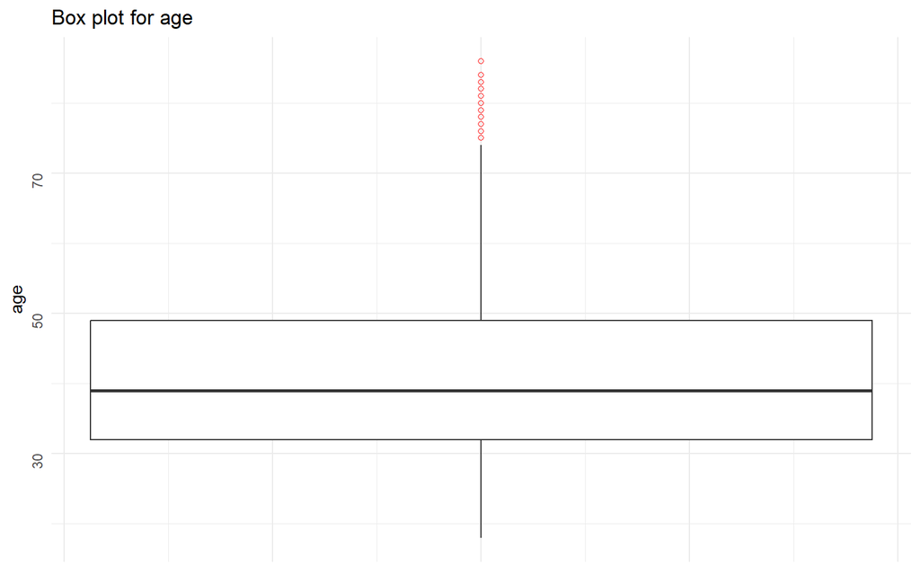

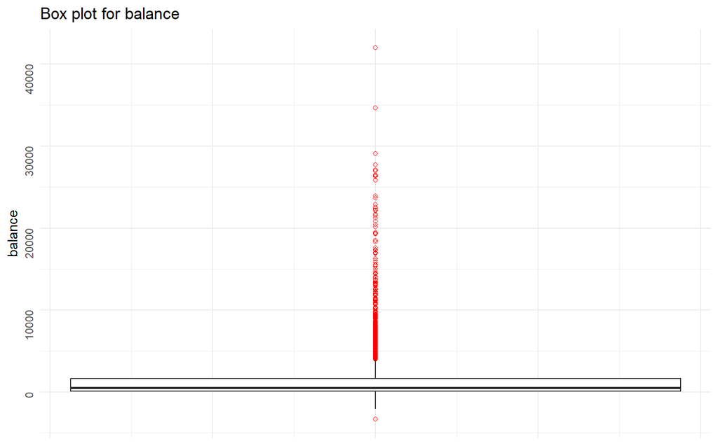

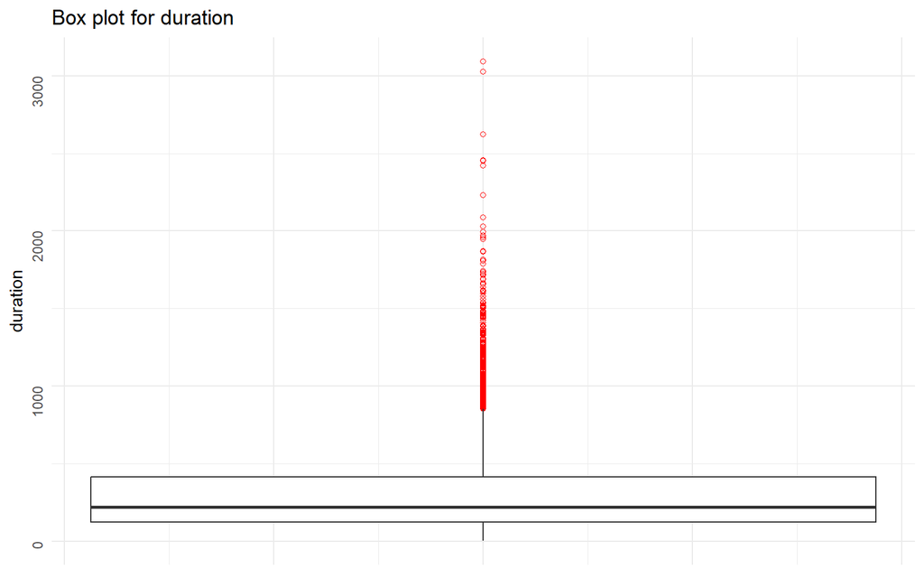

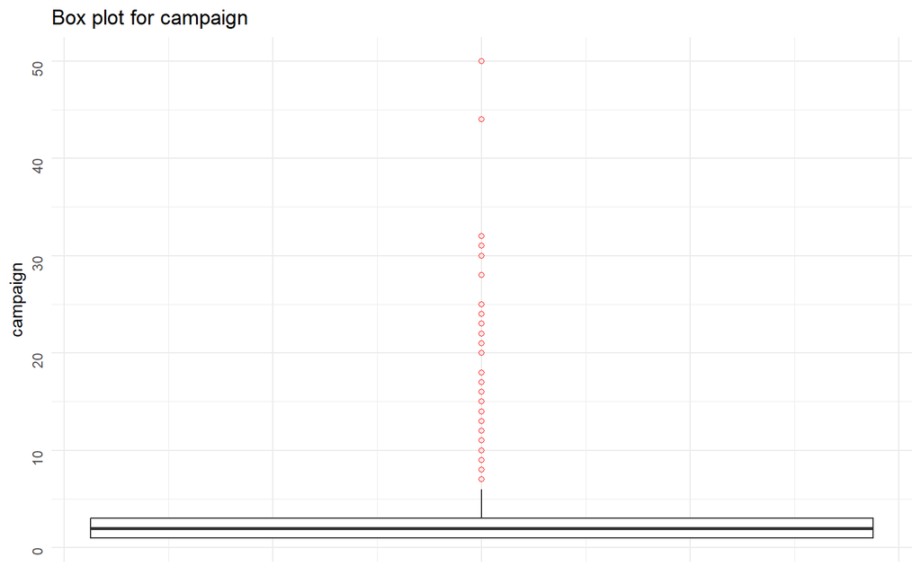

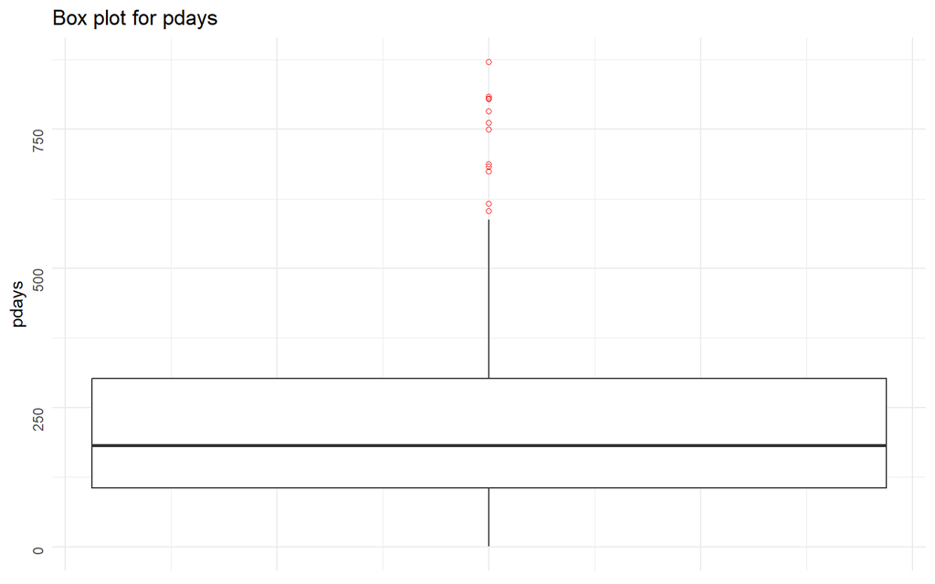

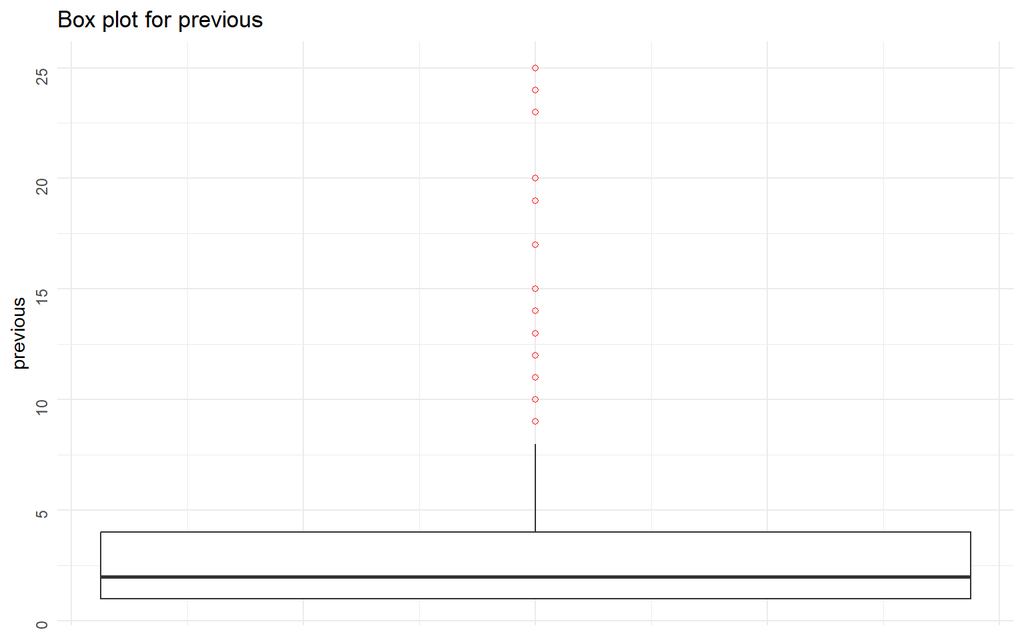

```r
plot_box_plots <- function(data) {
  numeric_columns <- sapply(data, is.numeric) & names(data) != "day"
  numeric_data <- data[numeric_columns]

  for (variable_name in names(numeric_data)) {
    if (variable_name == "pdays") {
      data_subset <- data[data[[variable_name]] != -1, variable_name, drop = FALSE]
    } else if (variable_name == "previous") {
      data_subset <- data[data[[variable_name]] != 0, variable_name, drop = FALSE]
    } else {
      data_subset <- data[, variable_name, drop = FALSE]
    }

    p <- ggplot(data_subset, aes_string(y = variable_name)) +
      geom_boxplot(outlier.colour = "red", outlier.shape = 1) +
      labs(title = paste("Box plot for", variable_name)) +
      theme_minimal() +
      theme(axis.title.x = element_blank(),
            axis.text.x = element_blank(),
            axis.ticks.x = element_blank(),
            axis.text.y = element_text(angle = 90, vjust = 0.5))
    print(p)
  }
}

plot_box_plots(my_data)
```

## Correlation analysis for numerical variables

```r
numerical_data <- my_data[sapply(my_data, is.numeric)]
correlation_matrix <- cor(numerical_data, use = "complete.obs")
print(correlation_matrix)
```

```
##                   age     balance          day     duration    campaign
## age       1.000000000 0.096199294 -0.025893547  0.006905514 -0.01160843
## balance   0.096199294 1.000000000  0.009146284  0.006326892  0.00751627
## day      -0.025893547 0.009146284  1.000000000 -0.011477417  0.14512964
## duration  0.006905514 0.006326892 -0.011477417  1.000000000 -0.05382066
## campaign -0.011608435 0.007516270  0.145129637 -0.053820656  1.00000000
## pdays    -0.006107752 0.007483178 -0.079736257 -0.012642312 -0.09531657
## previous  0.011047441 0.028008025 -0.058504360 -0.006607889 -0.07437766
##                 pdays     previous
## age      -0.006107752  0.011047441
## balance   0.007483178  0.028008025
## day      -0.079736257 -0.058504360
## duration -0.012642312 -0.006607889
## campaign -0.095316567 -0.074377657
## pdays     1.000000000  0.556200657
## previous  0.556200657  1.000000000
```

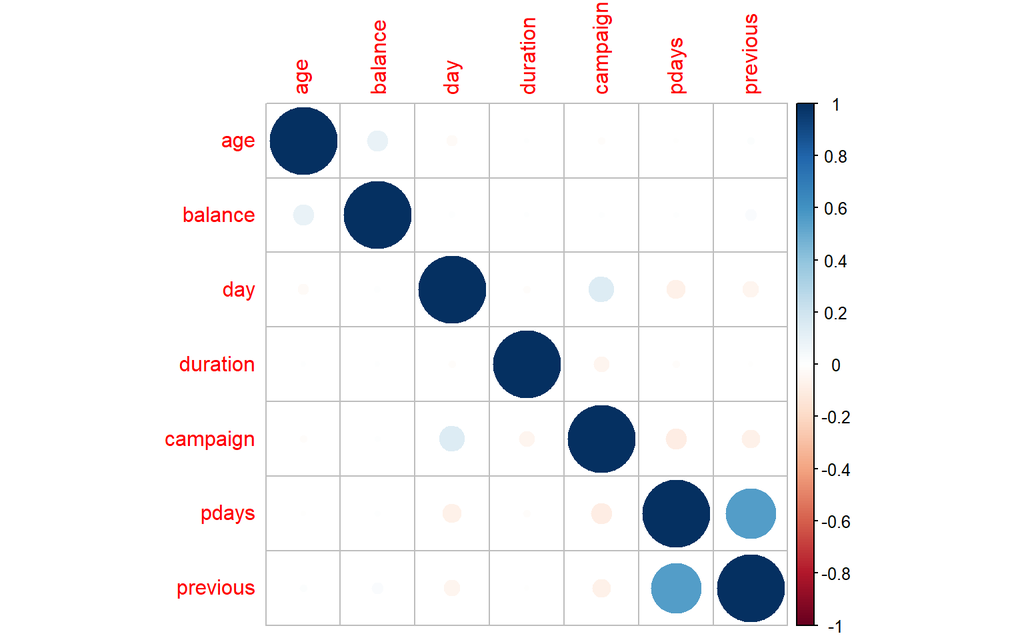

```r
corrplot(correlation_matrix, method = "circle")
```

As you can see from the correlation result, only the relationship between *pdays* and *previous* is significant (0.5562>0.5>>other). This means we could say that the number of days since the last contact increases, the number of contacts made before the current campaign also tends to be higher. The presence of the value -1 in *pdays*, which signifies that the client was not previously contacted, warrants special attention, as it could significantly influence the observed correlation and possibly lead to skewed results.

## Visualze the result from correlation

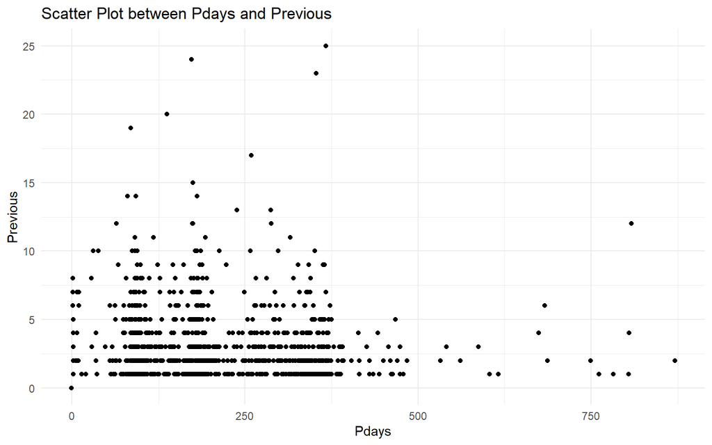

```r
ggplot(my_data, aes(x = pdays, y = previous)) +
  geom_point() +
  theme_minimal() +
  labs(x = "Pdays", y = "Previous", title = "Scatter Plot between Pdays and Previous")
```

## Frequency table for categorical variables

```r
categorical_data <- my_data[sapply(my_data, is.factor) | sapply(my_data, is.character)]
frequency_tables <- lapply(categorical_data, table)
print(frequency_tables)
```

```
## $job
##
##        admin.   blue-collar  entrepreneur     housemaid    management
##           521           963           167           121          1096
##       retired self-employed      services       student    technician
##           310           194           441           142           856
##    unemployed       unknown
##           151            38
##
## $marital
##
## divorced  married   single
##      584     2984     1432
##
## $education
##
##   primary secondary  tertiary   unknown
##       675      2525      1586       214
##
## $default
##
##   no  yes
## 4920   80
##
## $housing
##
##   no  yes
## 2389 2611
##
## $loan
##
##   no  yes
## 4298  702
##
## $contact
##
##  cellular telephone   unknown
##      3433       335      1232
##
## $month
##
##  apr  aug  dec  feb  jan  jul  jun  mar  may  nov  oct  sep
##  378  708   39  276  157  726  549   90 1400  437  129  111
##
## $poutcome
##
## failure   other success unknown
##     560     235     309    3896
##
## $y
##
##   no  yes
## 3412 1588
```

## Visualize frequency table for categorical variables

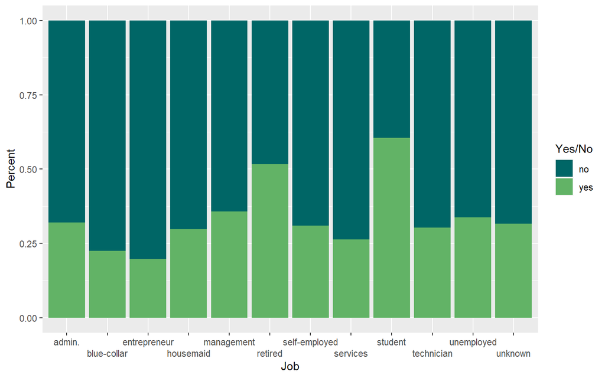

```r
ggplot() +
  geom_bar( data = my_data,
            aes( x = factor( job ),
                 fill = factor( y ) ),
            position = "fill" ) +
  scale_x_discrete( "Job", guide = guide_axis(n.dodge = 2) ) +
  scale_y_continuous( "Percent" ) +
  guides( fill = guide_legend( title = "Yes/No" ) ) +
  scale_fill_manual( values = c( "#006666", "#62b366" ) )
```

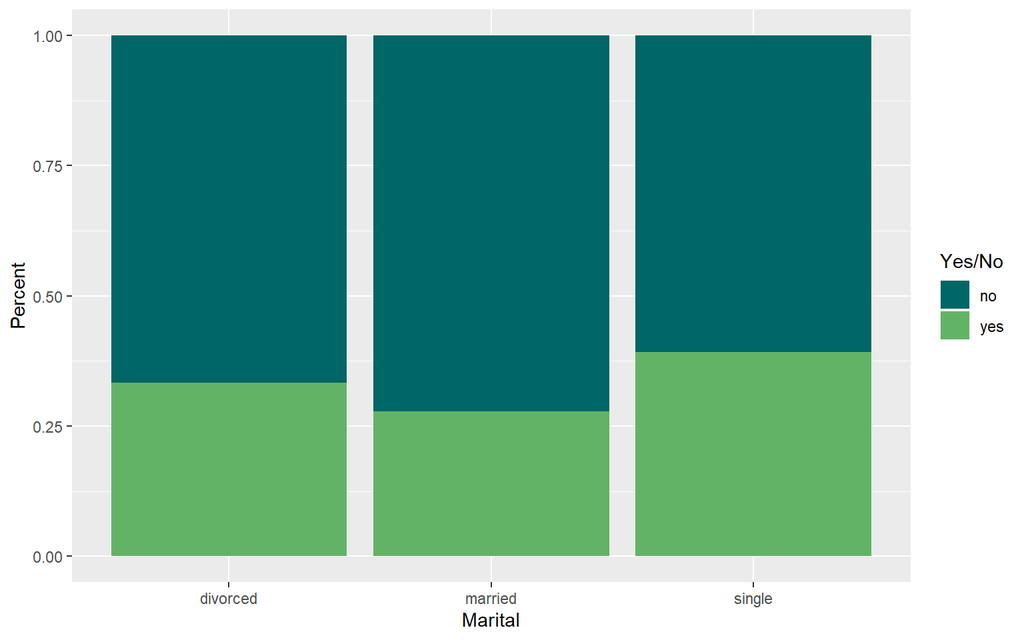

```r
ggplot() +
  geom_bar( data = my_data,
            aes( x = factor( marital ),
                 fill = factor( y ) ),
            position = "fill" ) +
  scale_x_discrete( "Marital" ) +
  scale_y_continuous( "Percent" ) +
  guides( fill = guide_legend( title = "Yes/No" ) ) +
  scale_fill_manual( values = c( "#006666", "#62b366" ) )
```

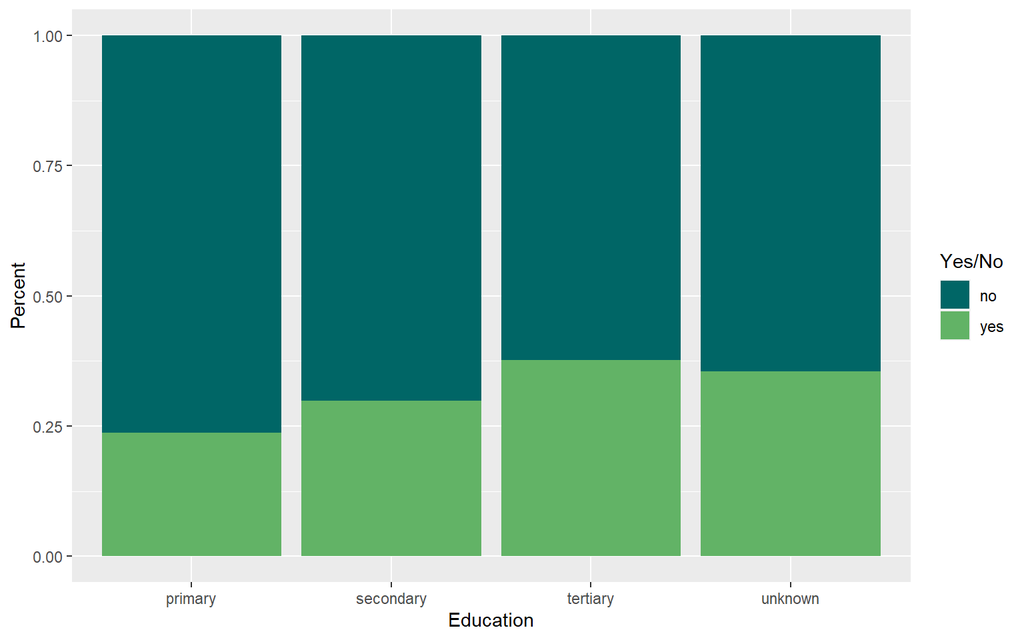

```r
ggplot() +
  geom_bar( data = my_data,
            aes( x = factor( education ),
                 fill = factor( y ) ),
            position = "fill" ) +
  scale_x_discrete( "Education" ) +
  scale_y_continuous( "Percent" ) +
  guides( fill = guide_legend( title = "Yes/No" ) ) +
  scale_fill_manual( values = c( "#006666", "#62b366" ) )
```

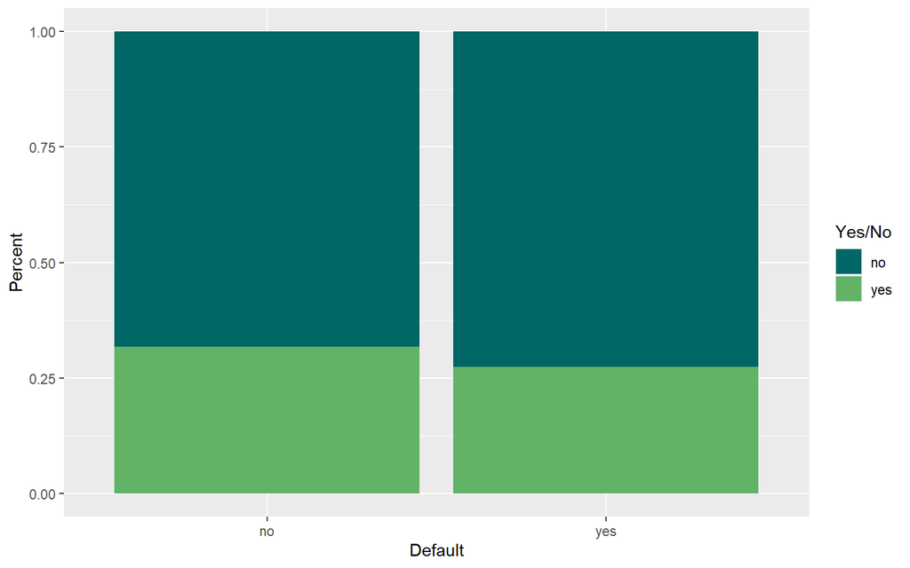

```r
ggplot() +
  geom_bar( data = my_data,
            aes( x = factor( default ),
                 fill = factor( y ) ),
            position = "fill" ) +
  scale_x_discrete( "Default" ) +
  scale_y_continuous( "Percent" ) +
  guides( fill = guide_legend( title = "Yes/No" ) ) +
  scale_fill_manual( values = c( "#006666", "#62b366" ) )
```

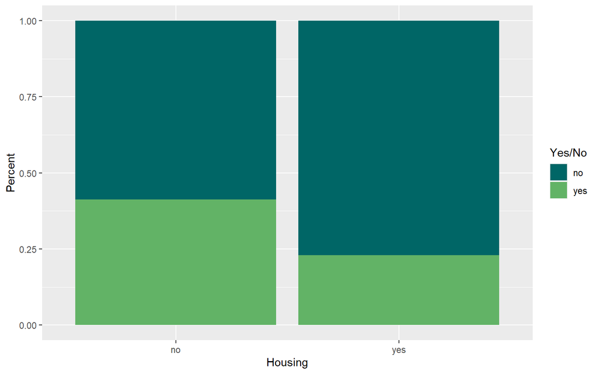

```r
ggplot() +
  geom_bar( data = my_data,
            aes( x = factor( housing ),
                 fill = factor( y ) ),
            position = "fill" ) +
  scale_x_discrete( "Housing" ) +
  scale_y_continuous( "Percent" ) +
  guides( fill = guide_legend( title = "Yes/No" ) ) +
  scale_fill_manual( values = c( "#006666", "#62b366" ) )
```

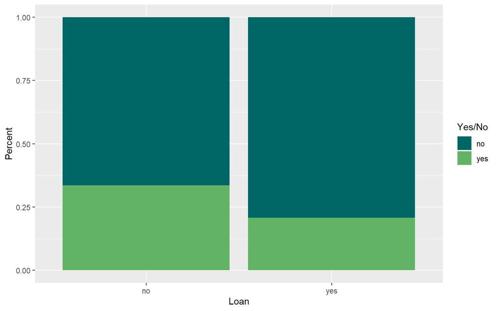

```r
ggplot() +
  geom_bar( data = my_data,
            aes( x = factor( loan ),
                 fill = factor( y ) ),
            position = "fill" ) +
  scale_x_discrete( "Loan" ) +
  scale_y_continuous( "Percent" ) +
  guides( fill = guide_legend( title = "Yes/No" ) ) +
  scale_fill_manual( values = c( "#006666", "#62b366" ) )
```

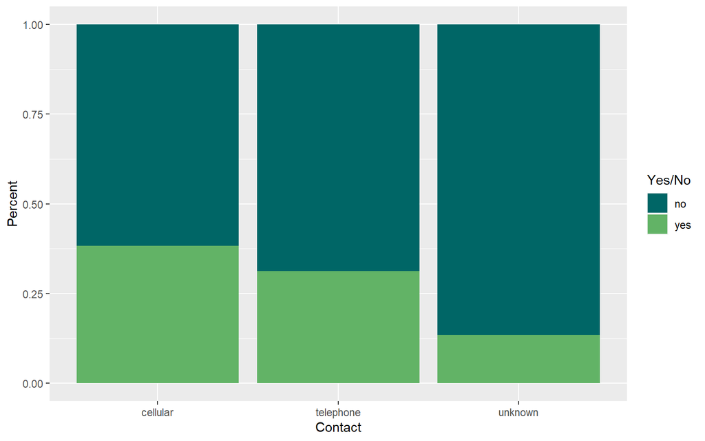

```r
ggplot() +
  geom_bar( data = my_data,
            aes( x = factor( contact ),
                 fill = factor( y ) ),
            position = "fill" ) +
  scale_x_discrete( "Contact" ) +
  scale_y_continuous( "Percent" ) +
  guides( fill = guide_legend( title = "Yes/No" ) ) +
  scale_fill_manual( values = c( "#006666", "#62b366" ) )
```

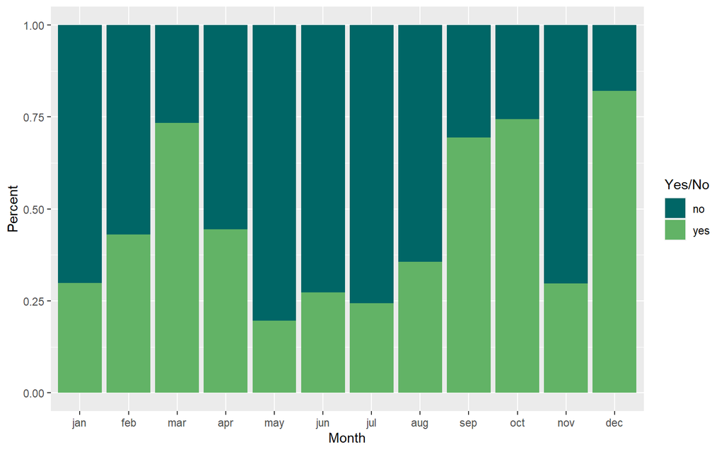

```r
my_data$month <- factor(my_data$month, levels = c("jan", "feb", "mar", "apr", "may", "jun", "jul", "aug", "sep", "oct", "nov", "dec"))

ggplot() +
  geom_bar( data = my_data,
            aes( x = factor( month ),
                 fill = factor( y ) ),
            position = "fill" ) +
  scale_x_discrete( "Month" ) +
  scale_y_continuous( "Percent" ) +
  guides( fill = guide_legend( title = "Yes/No" ) ) +
  scale_fill_manual( values = c( "#006666", "#62b366" ) )
```

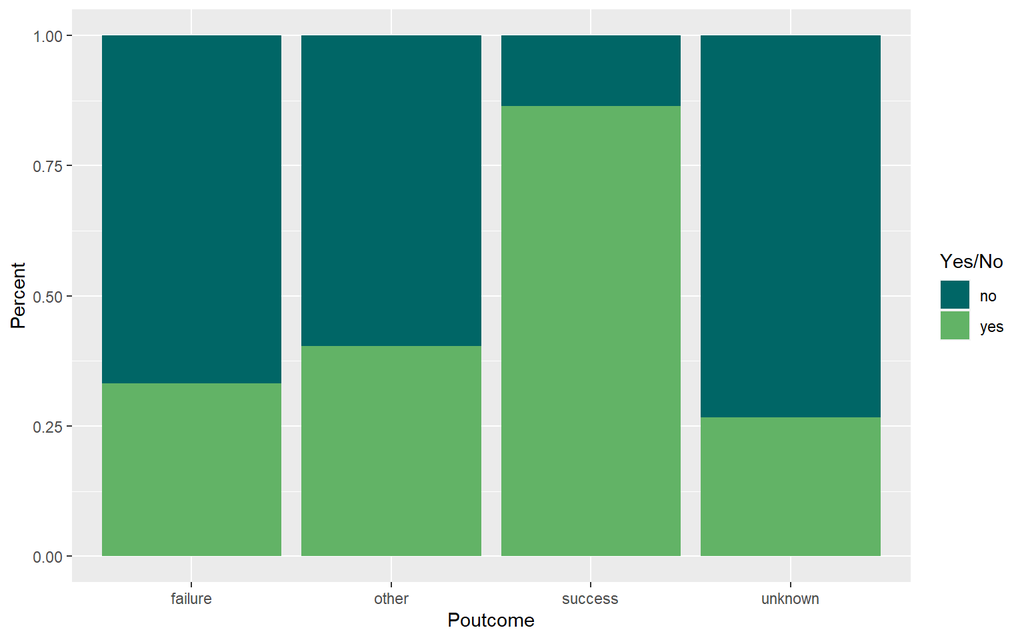

```r
ggplot() +
  geom_bar( data = my_data,
            aes( x = factor( poutcome ),
                 fill = factor( y ) ),
            position = "fill" ) +
  scale_x_discrete( "Poutcome" ) +
  scale_y_continuous( "Percent" ) +
  guides( fill = guide_legend( title = "Yes/No" ) ) +
  scale_fill_manual( values = c( "#006666", "#62b366" ) )
```

As you can see from the frequency table, in our database with 5000 observations we have:

- The job categories with the highest frequencies are management, blue-collar, and technician.

- The majority of individuals are married, followed by single and divorced.

- A large number of individuals have secondary education, followed by tertiary and primary.

- Very few individuals have defaulted on their credit

- The majority of individuals do not have a personal loan and have not subscribed

- Most contacts were made via cellular phones, with a small proportion by telephone and a notable number of contacts are listed as unknown

- A large number of individuals have secondary education, followed by tertiary and primary.

- The frequency of contact varies by month, with May having the highest frequency

## Create training and test dataset.

This code will take 80% of the *my_data* to the *trainData* to work with and 20% other to the *testData* to check our prediction.

```r
trainIndex <- sample(1:nrow(my_data), 0.8 * nrow(my_data))
trainData <-  my_data[trainIndex, ]
testData <- my_data[-trainIndex, ]
head(trainData, 3)
```

```
##      age          job marital education default balance housing loan  contact
## 2343  56 entrepreneur married   unknown      no     575      no   no  unknown
## 5743  36   management  single  tertiary      no     339      no   no cellular
## 5290  31   management  single secondary      no     202     yes   no cellular
##      day month duration campaign pdays previous poutcome   y
## 2343  20   jun       18        2    -1        0  unknown  no
## 5743  21   nov        6        6    -1        0  unknown  no
## 5290   8   jul      167        1    62        1  failure yes
```

## Validating the Partitioning

To check that there are no differences between the same variable in *trainData* and *testData*, I use Two-sample T-test to calculate the p-value to generate the conclusion.

```r
age_t <- t.test(trainData$age, testData$age)
print(age_t)
```

```
##
##  Welch Two Sample t-test
##
## data:  trainData$age and testData$age
## t = -0.020219, df = 1553.1, p-value = 0.9839
## alternative hypothesis: true difference in means is not equal to 0
## 95 percent confidence interval:
##  -0.7840994  0.7680994
## sample estimates:
## mean of x mean of y
##    41.146    41.154
```

```r
duration_t <- t.test(trainData$duration, testData$duration)
print(duration_t)
```

```
##
##  Welch Two Sample t-test
##
## data:  trainData$duration and testData$duration
## t = -0.096142, df = 1505.7, p-value = 0.9234
## alternative hypothesis: true difference in means is not equal to 0
## 95 percent confidence interval:
##  -23.24316  21.07116
## sample estimates:
## mean of x mean of y
##   326.496   327.582
```

```r
trainData$y_num <- ifelse(trainData$y == "yes", 1, 0)
testData$y_num <- ifelse(testData$y == "yes", 1, 0)

y_t <- t.test(trainData$y_num, testData$y_num)
print(y_t)
```

```
##
##  Welch Two Sample t-test
##
## data:  trainData$y_num and testData$y_num
## t = 1.8208, df = 1567.4, p-value = 0.06883
## alternative hypothesis: true difference in means is not equal to 0
## 95 percent confidence interval:
##  -0.002279428  0.061279428
## sample estimates:
## mean of x mean of y
##    0.3235    0.2940
```

As you can see from the result, p-value in all case is bigger than 0.05. So there’s no significant difference in the distribution between the *trainData* and *testData*, suggesting that the partitions are consistent with respect to these variables.

## Setting up before apply data mining methods.

```r
trainData$default_num <- ifelse(trainData$default == "yes", 1, 0)
testData$default_num <- ifelse(testData$default == "yes", 1, 0)

trainData$housing_num <- ifelse(trainData$housing == "yes", 1, 0)
testData$housing_num <- ifelse(testData$housing == "yes", 1, 0)

trainData$loan_num <- ifelse(trainData$loan == "yes", 1, 0)
testData$loan_num <- ifelse(testData$loan == "yes", 1, 0)

trainData$month_num <- match(tolower(trainData$month), tolower(month.abb))
testData$month_num <- match(tolower(testData$month), tolower(month.abb))
```

## Normalize data (Min-Max Normalization)

```r
normalize <- function(x){
  rng <- range(x,na.rm = TRUE)
  (x - rng[1]) / (rng[2] - rng[1])
}

trainData <- trainData %>% mutate(
  age.MM = normalize(age),
  balance.MM = normalize(balance),
  duration.MM = normalize(duration),
  campaign.MM = normalize(campaign),
  pdays.MM = normalize(pdays),
  previous.MM = normalize(previous)
)

testData <- testData %>% mutate(
  age.MM = normalize(age),
  balance.MM = normalize(balance),
  duration.MM = normalize(duration),
  campaign.MM = normalize(campaign),
  pdays.MM = normalize(pdays),
  previous.MM = normalize(previous)
)
```

## Linear Regression

```r
trainData$y_num <- as.numeric(as.character(trainData$y_num))

model <- lm(y_num ~ age.MM + default_num + balance.MM + housing_num + loan_num + day + month_num + duration.MM + campaign.MM + pdays.MM + previous, trainData)
summary(model)
```

```
##
## Call:
## lm(formula = y_num ~ age.MM + default_num + balance.MM + housing_num +
##     loan_num + day + month_num + duration.MM + campaign.MM +
##     pdays.MM + previous, data = trainData)
##
## Residuals:
##     Min      1Q  Median      3Q     Max
## -1.3979 -0.2623 -0.1076  0.3327  1.0714
##
## Coefficients:
##               Estimate Std. Error t value Pr(>|t|)
## (Intercept)  1.626e-01  2.861e-02   5.684 1.41e-08 ***
## age.MM      -4.498e-02  3.811e-02  -1.180   0.2380
## default_num  3.206e-02  5.091e-02   0.630   0.5290
## balance.MM   1.238e-01  1.007e-01   1.229   0.2190
## housing_num -1.863e-01  1.285e-02 -14.503  < 2e-16 ***
## loan_num    -1.045e-01  1.795e-02  -5.823 6.23e-09 ***
## day          1.722e-05  7.603e-04   0.023   0.9819
## month_num    4.826e-03  2.551e-03   1.892   0.0585 .
## duration.MM  2.173e+00  6.149e-02  35.347  < 2e-16 ***
## campaign.MM -5.437e-01  1.108e-01  -4.909 9.54e-07 ***
## pdays.MM     3.038e-01  6.208e-02   4.894 1.03e-06 ***
## previous     2.665e-02  4.020e-03   6.629 3.83e-11 ***
## ---
## Signif. codes:  0 '***' 0.001 '**' 0.01 '*' 0.05 '.' 0.1 ' ' 1
##
## Residual standard error: 0.3922 on 3988 degrees of freedom
## Multiple R-squared:  0.2992, Adjusted R-squared:  0.2973
## F-statistic: 154.8 on 11 and 3988 DF,  p-value: < 2.2e-16
```

We could see there are some variables that still have the p-value bigger than 0.05. So I remove them and run the linear regression again.

```r
model <- lm(y_num ~ housing_num + loan_num + duration.MM + campaign.MM + pdays.MM + previous, trainData)
summary(model)
```

```
##
## Call:
## lm(formula = y_num ~ housing_num + loan_num + duration.MM + campaign.MM +
##     pdays.MM + previous, data = trainData)
##
## Residuals:
##     Min      1Q  Median      3Q     Max
## -1.3942 -0.2617 -0.1068  0.3370  1.0417
##
## Coefficients:
##              Estimate Std. Error t value Pr(>|t|)
## (Intercept)  0.191566   0.012212  15.687  < 2e-16 ***
## housing_num -0.188131   0.012470 -15.087  < 2e-16 ***
## loan_num    -0.104324   0.017852  -5.844 5.51e-09 ***
## duration.MM  2.176299   0.061483  35.397  < 2e-16 ***
## campaign.MM -0.528031   0.109404  -4.826 1.44e-06 ***
## pdays.MM     0.293818   0.061886   4.748 2.13e-06 ***
## previous     0.027115   0.004014   6.755 1.64e-11 ***
## ---
## Signif. codes:  0 '***' 0.001 '**' 0.01 '*' 0.05 '.' 0.1 ' ' 1
##
## Residual standard error: 0.3923 on 3993 degrees of freedom
## Multiple R-squared:  0.298,  Adjusted R-squared:  0.297
## F-statistic: 282.5 on 6 and 3993 DF,  p-value: < 2.2e-16
```

Apply to the *testData*

```r
predictions_lr <- predict(model, newdata = testData)
residuals_lr <- testData$y_num - predictions_lr
rmse_lr <- sqrt(mean(residuals_lr^2, na.rm = TRUE))
print(rmse_lr)
```

```
## [1] 0.3905596
```

After running the linear regression, we could see that the R^2 is not really high - just around 0.3, and the Root-mean-square-error is 0.4. Which means only 30% of these observations can be explained by this system and on average, the model’s predictions are 0.4 units away from the actual data points, which is very high when the target variable is only 0 or 1. So I decided to change to another method for data mining.

## C5.0 Decision Tree

Same with the previous method. For C5.0 Decision Tree I also start with all variables, which gives us the result below.

```r
predictors <- trainData[,c(23,2,3,4,5,24,7,8,9,10,11,25,26,27,28,16)]
dependence <- trainData$y

c50fit <- C5.0(x = predictors, y = dependence)
c50fit
```

```
##
## Call:
## C5.0.default(x = predictors, y = dependence)
##
## Classification Tree
## Number of samples: 4000
## Number of predictors: 16
##
## Tree size: 79
##
## Non-standard options: attempt to group attributes
```

```r
summary(c50fit)
```

```
##
## Call:
## C5.0.default(x = predictors, y = dependence)
##
##
## C5.0 [Release 2.07 GPL Edition]      Thu Dec 21 23:18:05 2023
## -------------------------------
##
## Class specified by attribute `outcome'
##
## Read 4000 cases (17 attributes) from undefined.data
##
## Decision tree:
##
## poutcome = success:
## :...duration.MM > 0.05113269: yes (213/18)
## :   duration.MM <= 0.05113269:
## :   :...housing = no: yes (28/9)
## :       housing = yes: no (8/1)
## poutcome in {failure,other,unknown}:
## :...duration.MM > 0.1239482:
##     :...duration.MM > 0.2449838: yes (349/63)
##     :   duration.MM <= 0.2449838:
##     :   :...contact = unknown:
##     :       :...default = yes: yes (5/1)
##     :       :   default = no:
##     :       :   :...education in {primary,secondary,unknown}: no (123/33)
##     :       :       education = tertiary:
##     :       :       :...day > 21: yes (7)
##     :       :           day <= 21:
##     :       :           :...loan = yes: no (3)
##     :       :               loan = no:
##     :       :               :...job in {blue-collar,housemaid,technician,
##     :       :                   :       unemployed}: no (5)
##     :       :                   job in {admin.,entrepreneur,retired,
##     :       :                   :       self-employed,services,student,
##     :       :                   :       unknown}: yes (5)
##     :       :                   job = management:
##     :       :                   :...balance.MM <= 0.08322677: no (3)
##     :       :                       balance.MM > 0.08322677: yes (7/1)
```

[output cut: 156 more lines]

```
##   65.55% age.MM
##   42.83% day
##   34.00% job
##   20.52% housing
##   14.98% loan
##   10.57% education
##   10.30% previous.MM
##    6.50% default
##    2.28% campaign.MM
##    1.80% pdays.MM
##    0.47% balance.MM
##    0.30% marital
##
##
## Time: 0.0 secs
```

```r
predictors <- trainData[,c(23,7,8,9,10,11,25,28,16)]
dependence <- trainData$y

c50fit <- C5.0(x = predictors, y = dependence)
c50fit
```

```
##
## Call:
## C5.0.default(x = predictors, y = dependence)
##
## Classification Tree
## Number of samples: 4000
## Number of predictors: 9
##
## Tree size: 116
##
## Non-standard options: attempt to group attributes
```

```r
summary(c50fit)
```

```
##
## Call:
## C5.0.default(x = predictors, y = dependence)
##
##
## C5.0 [Release 2.07 GPL Edition]      Thu Dec 21 23:18:05 2023
## -------------------------------
##
## Class specified by attribute `outcome'
##
## Read 4000 cases (10 attributes) from undefined.data
##
## Decision tree:
##
## poutcome = success:
## :...duration.MM > 0.05113269: yes (213/18)
## :   duration.MM <= 0.05113269:
## :   :...housing = no: yes (28/9)
## :       housing = yes: no (8/1)
## poutcome in {failure,other,unknown}:
## :...duration.MM > 0.1239482:
##     :...duration.MM > 0.2449838: yes (349/63)
##     :   duration.MM <= 0.2449838:
##     :   :...contact = unknown:
##     :       :...month in {jan,feb,mar,apr,may,sep,oct,nov,dec}: no (102/30)
##     :       :   month in {jul,aug}: yes (5/1)
##     :       :   month = jun:
##     :       :   :...loan = yes: no (8/1)
##     :       :       loan = no:
##     :       :       :...housing = yes: yes (22/9)
##     :       :           housing = no:
##     :       :           :...duration.MM <= 0.2016181: no (13/1)
##     :       :               duration.MM > 0.2016181:
##     :       :               :...day <= 11: yes (4)
##     :       :                   day > 11:
##     :       :                   :...age.MM <= 0.3823529: yes (2)
##     :       :                       age.MM > 0.3823529: no (2)
##     :       contact in {cellular,telephone}:
##     :       :...loan = yes:
##     :           :...poutcome = other: yes (4)
```

[output cut: 205 more lines]

```
##
##  Attribute usage:
##
##  100.00% duration.MM
##  100.00% poutcome
##   83.45% month
##   80.45% contact
##   67.20% age.MM
##   46.97% day
##   23.13% housing
##   16.52% loan
##   13.02% previous.MM
##
##
## Time: 0.0 secs
```

Now we apply this method to our *testData* to check the accuracy.

```r
predictions <- predict(c50fit, newdata = testData)

y_true <- testData$y

y_true <- factor(y_true, levels = levels(predictions))

confusion_matrix <- confusionMatrix(predictions, y_true)

print(confusion_matrix)
```

```
## Confusion Matrix and Statistics
##
##           Reference
## Prediction  no yes
##        no  599  69
##        yes 107 225
##
##                Accuracy : 0.824
##                  95% CI : (0.799, 0.8471)
##     No Information Rate : 0.706
##     P-Value [Acc > NIR] : < 2.2e-16
##
##                   Kappa : 0.5914
##
##  Mcnemar's Test P-Value : 0.005287
##
##             Sensitivity : 0.8484
##             Specificity : 0.7653
##          Pos Pred Value : 0.8967
##          Neg Pred Value : 0.6777
##              Prevalence : 0.7060
##          Detection Rate : 0.5990
##    Detection Prevalence : 0.6680
##       Balanced Accuracy : 0.8069
##
##        'Positive' Class : no
##
```

The accuracy for the C5.0 Decision Tree is 0.824. If we compare to our Linear Regression method, we can see this one is better than the previous one (When the RMSE of Linear Regression is less than a half, 0.4). And the p-value in this method is less than 2.2e-16 (Less than 0.05), so we can conclude that the model is significant.

## k-Nearest Neighbor Predictions

Another method presented below is the knn method. There is no specific reason why I choose k = 5. There is no one-size-fits-all answer for the best k value, however in my opinion, 5 is not really small but not also really big so normally I will take that number.

Same with two previous methods, I also put all variables into the model, and then apply it to the *testData* and check for the accuracy.

```r
k <- 5
knn_model <- train(y ~ age.MM + job + marital + education + default + balance.MM + housing + loan + contact + day + month + duration.MM + campaign.MM + pdays.MM + previous.MM + poutcome, data = trainData, method = "knn", trControl = trainControl(method = "none"), tuneGrid = expand.grid(k = k))

print(knn_model)
```

```
## k-Nearest Neighbors
##
## 4000 samples
##   16 predictor
##    2 classes: 'no', 'yes'
##
## No pre-processing
## Resampling: None
```

```r
predictions <- predict(knn_model, newdata = testData)

confusionMatrix(predictions, testData$y)
```

```
## Confusion Matrix and Statistics
##
##           Reference
## Prediction  no yes
##        no  640 181
##        yes  66 113
##
##                Accuracy : 0.753
##                  95% CI : (0.725, 0.7795)
##     No Information Rate : 0.706
##     P-Value [Acc > NIR] : 0.0005242
##
##                   Kappa : 0.3283
##
##  Mcnemar's Test P-Value : 4.057e-13
##
##             Sensitivity : 0.9065
##             Specificity : 0.3844
##          Pos Pred Value : 0.7795
##          Neg Pred Value : 0.6313
##              Prevalence : 0.7060
##          Detection Rate : 0.6400
##    Detection Prevalence : 0.8210
##       Balanced Accuracy : 0.6454
##
##        'Positive' Class : no
##
```

## Comparision between models

After developing three distinct models — Linear Regression, C5.0 Decision Tree, and kNN — We observe that each model consistently exhibits p-values close to zero, indicating statistically significant predictors. Among these, the C5.0 Decision Tree model stands out with the highest accuracy, successfully predicting the correct outcome in 82.4% of cases. For the kNN model, accuracy could potentially be enhanced by optimizing the choice of k, which entails selecting the most appropriate number of neighbors — a task that can be challenging yet rewarding. The lower performance of the Linear Regression model could be attributed to the prevalence of categorical variables within the dataset, which, despite being encoded as binary values, may not lend themselves well to the assumptions of linear regression, thereby yielding lower accuracy.

## Declaration of Originality: Take Home Exam

By signing this statement, I hereby acknowledge the submitted Exam

Course code: EBC1045

Course name: Knowledge Discovery and Data Visualization

to be produced independently by me.

By signing this statement, I explicitly declare that I am aware of the fraud sanctions as stated in the Education and Examination Regulations (EERs) of SBE, Maastricht University.

Place: Maastricht, Netherlands.

Date: 12/21/2023.

First and last name: Harvey Nguyen.

Study programme: Business Analytics.

ID number: i6360050.

Passport/ Id card number: P00323926